# Starbucks Capstone Challenge

### Introduction

This data set contains simulated data that mimics customer behavior on the Starbucks rewards mobile app. Once every few days, Starbucks sends out an offer to users of the mobile app. An offer can be merely an advertisement for a drink or an actual offer such as a discount or BOGO (buy one get one free). Some users might not receive any offer during certain weeks.

Not all users receive the same offer, and that is the challenge to solve with this data set.

Every offer has a validity period before the offer expires. As an example, a BOGO offer might be valid for only 5 days. You'll see in the data set that informational offers have a validity period even though these ads are merely providing information about a product; for example, if an informational offer has 7 days of validity, you can assume the customer is feeling the influence of the offer for 7 days after receiving the advertisement.

## Data Understanding

```python
import pandas as pd
import numpy as np
import math
import json
import seaborn as sns
from datetime import datetime
%matplotlib inline
from matplotlib import pyplot as plt
```

```python
# read in the json files
portfolio = pd.read_json('portfolio.json', orient='records', lines=True)
profile = pd.read_json('profile.json', orient='records', lines=True)
transcript = pd.read_json('transcript.json', orient='records', lines=True)
```

- portfolio.json - Contains offer identifiers and offer meta data (e.g. duration, type, etc.)
- profile.json - Customer demographic data
- transcript.json - Describes customer transactions and when offers are received, viewed, and completed.

## Profile dataset

#### Customer profile record attributes:

age (int) - Customer age

became_member_on (int) - Date when customer created an app account

gender (str) - Customer gender (note some entries contain 'O' for other

rather than M or F)

id (str) - Customer id

income (float) - Customer's income

```python
profile.head()
```

|  | gender | age | id | became_member_on | income |
| --- | --- | --- | --- | --- | --- |
| 0 | None | 118 | 68be06ca386d4c31939f3a4f0e3dd783 | 20170212 | NaN |
| 1 | F | 55 | 0610b486422d4921ae7d2bf64640c50b | 20170715 | 112000.0 |
| 2 | None | 118 | 38fe809add3b4fcf9315a9694bb96ff5 | 20180712 | NaN |
| 3 | F | 75 | 78afa995795e4d85b5d9ceeca43f5fef | 20170509 | 100000.0 |
| 4 | None | 118 | a03223e636434f42ac4c3df47e8bac43 | 20170804 | NaN |

```python
profile.info()
```

```
<class 'pandas.core.frame.DataFrame'>
RangeIndex: 17000 entries, 0 to 16999
Data columns (total 5 columns):
 #   Column            Non-Null Count  Dtype
---  ------            --------------  -----
 0   gender            14825 non-null  object
 1   age               17000 non-null  int64
 2   id                17000 non-null  object
 3   became_member_on  17000 non-null  int64
 4   income            14825 non-null  float64
dtypes: float64(1), int64(2), object(2)
memory usage: 664.2+ KB
```

Number of customers: 17000

Number of colunms: 5

##### cleaning up

profile dataset the following was performed:

```python
def clean_profile_dataset(df):
    """
    performs the following:
        1- copy the data frame to wrangle the data
        2- convert 'became_member_on' column type to date
        3- create dataframe binary columns from each gender in 'gender' column then merge them with cleaned origianl data
        4- set missing date in 'age' column to nan instead of 118
        5- categorize customers in to their proper age category
        6- create dataframe binary columns from each age category in 'age_category' column then merge them with cleaned origianl data
        7- drop duplicated row if they exist
        8- rename 'id' column to 'user_id'

    args:
        df (Dataframe): the profile dataset dataframe

    return:
        df (Dataframe): the cleaned profile dataset dataframe
    """

    # copy the dataframe before wrangling the data
    df = df.copy()

    # drop duplicates
    print("number of duplicates: ", df.duplicated().sum())
    if df.duplicated().sum() > 0:
        df.drop_duplicates(keep = 'first', inplace = True)
        print("number of duplicates after the drop: ", df.duplicated().sum())

    # convert 'became_member_on' column type to date
    df['became_member_on'] = df['became_member_on'].apply(lambda x: datetime.strptime(str(x), '%Y%m%d') )

    # create dataframe binary columns from each gender in 'gender' column
    df_gender = pd.get_dummies(df['gender'],prefix="gender_")

    # merge dataframe binary columns from each gender in 'gender' column with cleaned origianl dataframe
    df = pd.concat([df, df_gender], axis=1)

    # set missing date in 'age' column to nan instead of 118
    df['age'] = df['age'].apply(lambda x: np.nan if x == 118 else x)

    # categorize customers in to their proper age category based categories on found in study in https://pubmed.ncbi.nlm.nih.gov/11815703/#:~:text=Participants%20were%20categorized%20by%20age,were%20compared%20across%20the%20groups.
    df['age_category']  = pd.cut(df['age'], bins=[18,35,55,118], labels=['young-adult','adult','elderly'], right=False)

    # create dataframe binary columns from each gender in 'gender' column
    df_age_category = pd.get_dummies(df['age_category'])

    # merge dataframe binary columns from each gender in 'gender' column with cleaned origianl dataframe
    df = pd.concat([df, df_age_category], axis=1)

    # rename 'id' column to 'user_id'
    df.rename(columns={'id':'customer_id'}, inplace=True)

    return df

profile = clean_profile_dataset(profile)
```

```
number of duplicates:  0
```

```python
profile.head()
```

|  | gender | age | customer_id | became_member_on | income | gender__F | gender__M | gender__O | age_category | young-adult | adult | elderly |
| --- | --- | --- | --- | --- | --- | --- | --- | --- | --- | --- | --- | --- |
| 0 | None | NaN | 68be06ca386d4c31939f3a4f0e3dd783 | 2017-02-12 | NaN | 0 | 0 | 0 | NaN | 0 | 0 | 0 |
| 1 | F | 55.0 | 0610b486422d4921ae7d2bf64640c50b | 2017-07-15 | 112000.0 | 1 | 0 | 0 | elderly | 0 | 0 | 1 |
| 2 | None | NaN | 38fe809add3b4fcf9315a9694bb96ff5 | 2018-07-12 | NaN | 0 | 0 | 0 | NaN | 0 | 0 | 0 |
| 3 | F | 75.0 | 78afa995795e4d85b5d9ceeca43f5fef | 2017-05-09 | 100000.0 | 1 | 0 | 0 | elderly | 0 | 0 | 1 |
| 4 | None | NaN | a03223e636434f42ac4c3df47e8bac43 | 2017-08-04 | NaN | 0 | 0 | 0 | NaN | 0 | 0 | 0 |

```python
#finding unique customer
len(profile['customer_id'].unique())
```

```
17000
```

```python
#Check missing values
profile.isnull().sum(0)
```

```
gender              2175
age                 2175
customer_id            0
became_member_on       0
income              2175
gender__F              0
gender__M              0
gender__O              0
age_category        2175
young-adult            0
adult                  0
elderly                0
dtype: int64
```

```python
#Drop the rows with missing gender income
profile.dropna(inplace=True)
```

### Portfolio dataset

###### The information provided about the offers is that there are 3 different types of offers:

BOGO - Buy One Get One For Free

Discount - discount upon purchase

Informative - provides information about products

```python
portfolio
```

|  | reward | channels | difficulty | duration | offer_type | id |
| --- | --- | --- | --- | --- | --- | --- |
| 0 | 10 | [email, mobile, social] | 10 | 7 | bogo | ae264e3637204a6fb9bb56bc8210ddfd |
| 1 | 10 | [web, email, mobile, social] | 10 | 5 | bogo | 4d5c57ea9a6940dd891ad53e9dbe8da0 |
| 2 | 0 | [web, email, mobile] | 0 | 4 | informational | 3f207df678b143eea3cee63160fa8bed |
| 3 | 5 | [web, email, mobile] | 5 | 7 | bogo | 9b98b8c7a33c4b65b9aebfe6a799e6d9 |
| 4 | 5 | [web, email] | 20 | 10 | discount | 0b1e1539f2cc45b7b9fa7c272da2e1d7 |
| 5 | 3 | [web, email, mobile, social] | 7 | 7 | discount | 2298d6c36e964ae4a3e7e9706d1fb8c2 |
| 6 | 2 | [web, email, mobile, social] | 10 | 10 | discount | fafdcd668e3743c1bb461111dcafc2a4 |
| 7 | 0 | [email, mobile, social] | 0 | 3 | informational | 5a8bc65990b245e5a138643cd4eb9837 |
| 8 | 5 | [web, email, mobile, social] | 5 | 5 | bogo | f19421c1d4aa40978ebb69ca19b0e20d |
| 9 | 2 | [web, email, mobile] | 10 | 7 | discount | 2906b810c7d4411798c6938adc9daaa5 |

```python
portfolio['offer_type'].unique()
```

```
array(['bogo', 'informational', 'discount'], dtype=object)
```

```python
profile.info()
```

```
<class 'pandas.core.frame.DataFrame'>
Int64Index: 14825 entries, 1 to 16999
Data columns (total 12 columns):
 #   Column            Non-Null Count  Dtype
---  ------            --------------  -----
 0   gender            14825 non-null  object
 1   age               14825 non-null  float64
 2   customer_id       14825 non-null  object
 3   became_member_on  14825 non-null  datetime64[ns]
 4   income            14825 non-null  float64
 5   gender__F         14825 non-null  uint8
 6   gender__M         14825 non-null  uint8
 7   gender__O         14825 non-null  uint8
 8   age_category      14825 non-null  category
 9   young-adult       14825 non-null  uint8
 10  adult             14825 non-null  uint8
 11  elderly           14825 non-null  uint8
dtypes: category(1), datetime64[ns](1), float64(2), object(2), uint8(6)
memory usage: 796.4+ KB
```

##### cleaning up

portfolio dataset the following was performed:

```python
def clean_portfolio_dataset(df):
    """
    performs the following:
        1- copy the dataframe to wrangle the data
        2- create binary columns from each channel in 'channels' column
        3- create binary columns from each offer type in 'offer_type' column then merge them with cleaned origianl dataframe
        4- drop 'offer_type' and channels columns from cleaned origianl dataframe
        5- drop duplicated row if they exist

    args:
        df (Dataframe): the offers portfolio dataset dataframe

    return:
        df (Dataframe): the cleaned offers portfolio dataset dataframe
    """

    # copy the dataframe before wrangling the data
    df = df.copy()

    #get the list of unique 'channels'
    channels = set()
    for row in df.channels:
        channels = channels.union(set(row))

    # create binary columns from each channel in 'channels' column
    for channel in channels:
        df[channel] =  df['channels'].apply(lambda x: 1 if channel in x else 0)

    # create dataframe binary columns from each offer type in 'offer_type' column
    df_offer_type = pd.get_dummies(df['offer_type'])

    # merge dataframe binary columns from each offer type in 'offer_type' column with cleaned origianl dataframe
    df = pd.concat([df, df_offer_type], axis=1)

    # drop 'offer_type' and channels columns from cleaned origianl dataframe
    df.drop(['channels'], axis = 1, inplace=True)

    # drop duplicates
    print("number of duplicates: ", df.duplicated().sum())
    if df.duplicated().sum() > 0:
        df.drop_duplicates(keep = 'first', inplace = True)
        print("number of duplicates after the drop: ", df.duplicated().sum())


    # rename 'id' column to 'offer_id'
    df.rename(columns={'id':'offer_id'}, inplace=True)

    return df
```

```python
portfolio = clean_portfolio_dataset(portfolio)
portfolio
```

```
number of duplicates:  0
```

|  | reward | difficulty | duration | offer_type | offer_id | mobile | web | email | social | bogo | discount | informational |
| --- | --- | --- | --- | --- | --- | --- | --- | --- | --- | --- | --- | --- |
| 0 | 10 | 10 | 7 | bogo | ae264e3637204a6fb9bb56bc8210ddfd | 1 | 0 | 1 | 1 | 1 | 0 | 0 |
| 1 | 10 | 10 | 5 | bogo | 4d5c57ea9a6940dd891ad53e9dbe8da0 | 1 | 1 | 1 | 1 | 1 | 0 | 0 |
| 2 | 0 | 0 | 4 | informational | 3f207df678b143eea3cee63160fa8bed | 1 | 1 | 1 | 0 | 0 | 0 | 1 |
| 3 | 5 | 5 | 7 | bogo | 9b98b8c7a33c4b65b9aebfe6a799e6d9 | 1 | 1 | 1 | 0 | 1 | 0 | 0 |
| 4 | 5 | 20 | 10 | discount | 0b1e1539f2cc45b7b9fa7c272da2e1d7 | 0 | 1 | 1 | 0 | 0 | 1 | 0 |
| 5 | 3 | 7 | 7 | discount | 2298d6c36e964ae4a3e7e9706d1fb8c2 | 1 | 1 | 1 | 1 | 0 | 1 | 0 |
| 6 | 2 | 10 | 10 | discount | fafdcd668e3743c1bb461111dcafc2a4 | 1 | 1 | 1 | 1 | 0 | 1 | 0 |
| 7 | 0 | 0 | 3 | informational | 5a8bc65990b245e5a138643cd4eb9837 | 1 | 0 | 1 | 1 | 0 | 0 | 1 |
| 8 | 5 | 5 | 5 | bogo | f19421c1d4aa40978ebb69ca19b0e20d | 1 | 1 | 1 | 1 | 1 | 0 | 0 |
| 9 | 2 | 10 | 7 | discount | 2906b810c7d4411798c6938adc9daaa5 | 1 | 1 | 1 | 0 | 0 | 1 | 0 |

```python
#Check missing values
portfolio.isnull().sum(0)
```

```
reward           0
difficulty       0
duration         0
offer_type       0
offer_id         0
mobile           0
web              0
email            0
social           0
bogo             0
discount         0
informational    0
dtype: int64
```

There is no null values in portfolio database

### Transcript dataset

###### Customer transaction record attributes :

event (str) - Record description (i.e. transaction, offer received, offer viewed, etc.)

person (str) - Customer id

time (int) - Time in hours. The data begins at time t=0

value - (dict of strings) - Either an offer id or transaction amount depending on the record

```python
transcript.head()
```

|  | person | event | value | time |
| --- | --- | --- | --- | --- |
| 0 | 78afa995795e4d85b5d9ceeca43f5fef | offer received | {'offer id': '9b98b8c7a33c4b65b9aebfe6a799e6d9'} | 0 |
| 1 | a03223e636434f42ac4c3df47e8bac43 | offer received | {'offer id': '0b1e1539f2cc45b7b9fa7c272da2e1d7'} | 0 |
| 2 | e2127556f4f64592b11af22de27a7932 | offer received | {'offer id': '2906b810c7d4411798c6938adc9daaa5'} | 0 |
| 3 | 8ec6ce2a7e7949b1bf142def7d0e0586 | offer received | {'offer id': 'fafdcd668e3743c1bb461111dcafc2a4'} | 0 |
| 4 | 68617ca6246f4fbc85e91a2a49552598 | offer received | {'offer id': '4d5c57ea9a6940dd891ad53e9dbe8da0'} | 0 |

```python
transcript.info()
```

```
<class 'pandas.core.frame.DataFrame'>
RangeIndex: 306534 entries, 0 to 306533
Data columns (total 4 columns):
 #   Column  Non-Null Count   Dtype
---  ------  --------------   -----
 0   person  306534 non-null  object
 1   event   306534 non-null  object
 2   value   306534 non-null  object
 3   time    306534 non-null  int64
dtypes: int64(1), object(3)
memory usage: 9.4+ MB
```

#### cleaning up

transcript dataset the following was performed:

```python
def extarct_value_column_values_to_transaction_amount_column(transcript):
    """
    extarct 'value' column values from to separate column:
        - if the event column value is 'transaction' then extarct 'amount' value to 'transaction_amount' column

    args:
       transcript (Series): row from transcript datafteme

    return:
       float as transaction_amount or Nan

    """
    if transcript['event'] == 'transaction':
        return transcript['value']['amount']
    else:
        return np.nan

def extarct_value_column_values_to_offer_id_column(transcript):
    """
    extarct 'value' column values from to separate columns:
        - if the event column value is not 'transaction' then extarct 'offer id' value to 'offer_id' column

    args:
       transcript (Series): row from transcript datafteme

    return:
        String as offer_id or None
    """
    if transcript['event'] != 'transaction':
        if 'offer id'in transcript['value'].keys() :
            return transcript['value']['offer id']
        else:
            return transcript['value']['offer_id']
    else:
        return None


def clean_transcript_dataset(df):
    """
    performs the following:
        1- copy the dataframe to wrangle the data
        2- create new 'offer_id' and 'transaction_amount' columns with null values
        3- extarct 'transaction_amount' column values from value column values
        4- extarct 'offer_id' column values from value column values
        5- create binary columns from each transcript event type in 'event' column then merge them with cleaned origianl dataframe
        6- drop 'value' and 'event' columns from cleaned origianl dataframe
        7- drop duplicated row if they exist
        8- rename 'person' column to 'uesr_id'

    args:
        df (Dataframe): the offers transcript dataset dataframe

    return:
        df (Dataframe): the cleaned offers transcript dataset dataframe
    """

    # copy the dataframe before wrangling the data
    df = df.copy()

    # create new 'offer_id' and 'transaction_amount' columns with null values
    df['offer_id'] = None
    df['transaction_amount'] = np.nan

    # extarct 'transaction_amount' column values from 'value' column values
    df['transaction_amount'] = df.apply(lambda row : extarct_value_column_values_to_transaction_amount_column(row),axis=1)

    # extarct 'offer_id' column values from 'value' column values
    df['offer_id'] = df.apply(lambda row : extarct_value_column_values_to_offer_id_column(row),axis=1)


    # create dataframe binary columns from each transcript event in 'event' column
    df_event = pd.get_dummies(df['event'])

    # merge dataframe binary columns from each transcript event in 'event' column with cleaned origianl dataframe
    df = pd.concat([df, df_event], axis=1)

    # drop 'value' and 'event' columns from cleaned origianl dataframe
    df.drop(['value'], axis = 1, inplace=True)

    # drop duplicates
    print("number of duplicates: ", df.duplicated().sum())
    if df.duplicated().sum() > 0:
        df.drop_duplicates(keep = 'first', inplace = True)
        print("number of duplicates after the drop: ", df.duplicated().sum())

    # rename 'person' column to 'uesr_id'
    df.rename(columns={'person':'customer_id'}, inplace=True)

    return df
```

```python
transcript = clean_transcript_dataset(transcript)
transcript
```

```
number of duplicates:  397
number of duplicates after the drop:  0
```

|  | customer_id | event | time | offer_id | transaction_amount | offer completed | offer received | offer viewed | transaction |
| --- | --- | --- | --- | --- | --- | --- | --- | --- | --- |
| 0 | 78afa995795e4d85b5d9ceeca43f5fef | offer received | 0 | 9b98b8c7a33c4b65b9aebfe6a799e6d9 | NaN | 0 | 1 | 0 | 0 |
| 1 | a03223e636434f42ac4c3df47e8bac43 | offer received | 0 | 0b1e1539f2cc45b7b9fa7c272da2e1d7 | NaN | 0 | 1 | 0 | 0 |
| 2 | e2127556f4f64592b11af22de27a7932 | offer received | 0 | 2906b810c7d4411798c6938adc9daaa5 | NaN | 0 | 1 | 0 | 0 |
| 3 | 8ec6ce2a7e7949b1bf142def7d0e0586 | offer received | 0 | fafdcd668e3743c1bb461111dcafc2a4 | NaN | 0 | 1 | 0 | 0 |
| 4 | 68617ca6246f4fbc85e91a2a49552598 | offer received | 0 | 4d5c57ea9a6940dd891ad53e9dbe8da0 | NaN | 0 | 1 | 0 | 0 |
| ... | ... | ... | ... | ... | ... | ... | ... | ... | ... |
| 306529 | b3a1272bc9904337b331bf348c3e8c17 | transaction | 714 | None | 1.59 | 0 | 0 | 0 | 1 |
| 306530 | 68213b08d99a4ae1b0dcb72aebd9aa35 | transaction | 714 | None | 9.53 | 0 | 0 | 0 | 1 |
| 306531 | a00058cf10334a308c68e7631c529907 | transaction | 714 | None | 3.61 | 0 | 0 | 0 | 1 |
| 306532 | 76ddbd6576844afe811f1a3c0fbb5bec | transaction | 714 | None | 3.53 | 0 | 0 | 0 | 1 |
| 306533 | c02b10e8752c4d8e9b73f918558531f7 | transaction | 714 | None | 4.05 | 0 | 0 | 0 | 1 |

306137 rows × 9 columns

```python
transcript['time'] /= 24.0
```

```python
transcript.event.value_counts()
```

```
transaction        138953
offer received      76277
offer viewed        57725
offer completed     33182
Name: event, dtype: int64
```

## Combine Customer Transaction, Demographic and Offer Data

```python
# merge transcript_clean with portfolio_clean on offer_id
df_starbucks_master = transcript.merge(portfolio,on='offer_id',how='left')

# merge the merged transcript_clean with portfolio_clean datasets to profile_clean on user_id
df_starbucks_master = df_starbucks_master.merge(profile,on='customer_id',how='left')
df_starbucks_master
```

|  | customer_id | event | time | offer_id | transaction_amount | offer completed | offer received | offer viewed | transaction | reward | ... | age | became_member_on | income | gender__F | gender__M | gender__O | age_category | young-adult | adult | elderly |
| --- | --- | --- | --- | --- | --- | --- | --- | --- | --- | --- | --- | --- | --- | --- | --- | --- | --- | --- | --- | --- | --- |
| 0 | 78afa995795e4d85b5d9ceeca43f5fef | offer received | 0.00 | 9b98b8c7a33c4b65b9aebfe6a799e6d9 | NaN | 0 | 1 | 0 | 0 | 5.0 | ... | 75.0 | 2017-05-09 | 100000.0 | 1.0 | 0.0 | 0.0 | elderly | 0.0 | 0.0 | 1.0 |
| 1 | a03223e636434f42ac4c3df47e8bac43 | offer received | 0.00 | 0b1e1539f2cc45b7b9fa7c272da2e1d7 | NaN | 0 | 1 | 0 | 0 | 5.0 | ... | NaN | NaT | NaN | NaN | NaN | NaN | NaN | NaN | NaN | NaN |
| 2 | e2127556f4f64592b11af22de27a7932 | offer received | 0.00 | 2906b810c7d4411798c6938adc9daaa5 | NaN | 0 | 1 | 0 | 0 | 2.0 | ... | 68.0 | 2018-04-26 | 70000.0 | 0.0 | 1.0 | 0.0 | elderly | 0.0 | 0.0 | 1.0 |
| 3 | 8ec6ce2a7e7949b1bf142def7d0e0586 | offer received | 0.00 | fafdcd668e3743c1bb461111dcafc2a4 | NaN | 0 | 1 | 0 | 0 | 2.0 | ... | NaN | NaT | NaN | NaN | NaN | NaN | NaN | NaN | NaN | NaN |
| 4 | 68617ca6246f4fbc85e91a2a49552598 | offer received | 0.00 | 4d5c57ea9a6940dd891ad53e9dbe8da0 | NaN | 0 | 1 | 0 | 0 | 10.0 | ... | NaN | NaT | NaN | NaN | NaN | NaN | NaN | NaN | NaN | NaN |
| ... | ... | ... | ... | ... | ... | ... | ... | ... | ... | ... | ... | ... | ... | ... | ... | ... | ... | ... | ... | ... | ... |
| 306132 | b3a1272bc9904337b331bf348c3e8c17 | transaction | 29.75 | None | 1.59 | 0 | 0 | 0 | 1 | NaN | ... | 66.0 | 2018-01-01 | 47000.0 | 0.0 | 1.0 | 0.0 | elderly | 0.0 | 0.0 | 1.0 |
| 306133 | 68213b08d99a4ae1b0dcb72aebd9aa35 | transaction | 29.75 | None | 9.53 | 0 | 0 | 0 | 1 | NaN | ... | 52.0 | 2018-04-08 | 62000.0 | 0.0 | 1.0 | 0.0 | adult | 0.0 | 1.0 | 0.0 |
| 306134 | a00058cf10334a308c68e7631c529907 | transaction | 29.75 | None | 3.61 | 0 | 0 | 0 | 1 | NaN | ... | 63.0 | 2013-09-22 | 52000.0 | 1.0 | 0.0 | 0.0 | elderly | 0.0 | 0.0 | 1.0 |
| 306135 | 76ddbd6576844afe811f1a3c0fbb5bec | transaction | 29.75 | None | 3.53 | 0 | 0 | 0 | 1 | NaN | ... | 57.0 | 2016-07-09 | 40000.0 | 0.0 | 1.0 | 0.0 | elderly | 0.0 | 0.0 | 1.0 |
| 306136 | c02b10e8752c4d8e9b73f918558531f7 | transaction | 29.75 | None | 4.05 | 0 | 0 | 0 | 1 | NaN | ... | NaN | NaT | NaN | NaN | NaN | NaN | NaN | NaN | NaN | NaN |

306137 rows × 31 columns

```python
df_starbucks_master.info();
```

```
<class 'pandas.core.frame.DataFrame'>
Int64Index: 306137 entries, 0 to 306136
Data columns (total 31 columns):
 #   Column              Non-Null Count   Dtype
---  ------              --------------   -----
 0   customer_id         306137 non-null  object
 1   event               306137 non-null  object
 2   time                306137 non-null  float64
 3   offer_id            167184 non-null  object
 4   transaction_amount  138953 non-null  float64
 5   offer completed     306137 non-null  uint8
 6   offer received      306137 non-null  uint8
 7   offer viewed        306137 non-null  uint8
 8   transaction         306137 non-null  uint8
 9   reward              167184 non-null  float64
```

[output cut: 23 more lines]

# Data Analysis and visualizations.

In this section, I will attempt to answer the problem statement questions

The questions are:

- What are the overall sex, age, and income distributions of customers?
- What is the distribution of the offer types alone and based on the gender and age category of customers that completed the offers?

## What are the overall gender , age, and income distributions of customers?

### Age Distribution

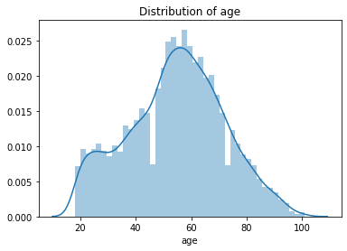

```python
# Plot distribution of ages in profile dataframe
ax = sns.distplot(profile['age']);
ax.set_title('Distribution of age');
```

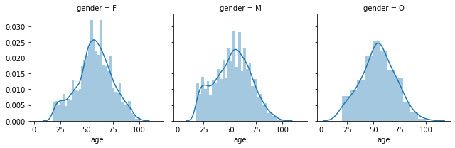

```python
#plot Age distribution by gender
g = sns.FacetGrid(profile, col='gender', col_wrap=3 )
g.map(sns.distplot, 'age');
```

> You can see from the age distribution that the average income is 54 of the majority profiles ages clustered below the average.

> All three genders are normal distribution,There are some deviations in the “female”, and especially for the “male” sex, in the early 20 age group.

### Income Distribution

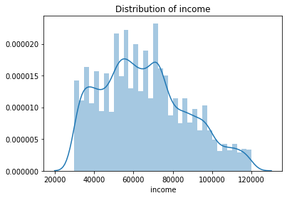

```python
# Plot distribution of incom in profile dataframe
ax = sns.distplot(profile['income']);
ax.set_title('Distribution of income');
```

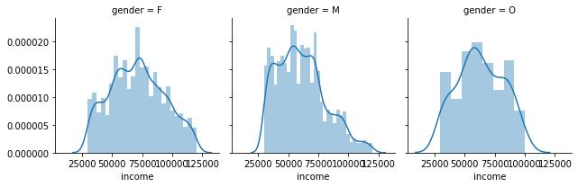

```python
#plot Income distribution by gender
g = sns.FacetGrid(profile, col='gender', col_wrap=3 )
g.map(sns.distplot, 'income');
```

```python
profile.income.mean()
```

```
65404.9915682968
```

> You can see from the income distribution that the average income is ~65,400 of the majority profiles have income are clustered below the average.

> All three genders are also almost normally distributed. The male part of Starbucks customers, it has a slight right-skewed shape, which means that Starbucks is preferred by lower-income males.

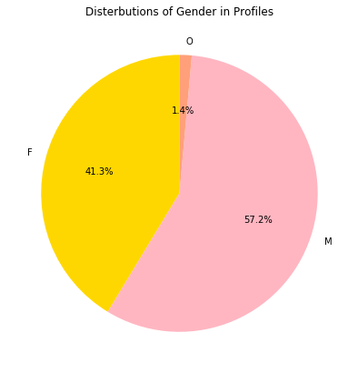

```python
ax = profile.groupby('gender').customer_id.count().plot(kind='pie' ,figsize=(7,7)  , startangle=90, autopct='%1.1f%%',
                                                        title= "Disterbutions of Gender in Profiles" ,
                                                        colors = ['gold', 'lightpink', 'lightsalmon']);
ax.set_ylabel("");
```

> You can see from the gender distribution in the profile dataset that the number of male profiles is greater than that of females, and that "other" represents 1.4% of the values.

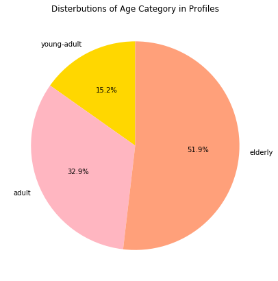

```python
ax= profile.groupby('age_category').customer_id.count().plot(kind='pie' ,figsize=(7,7)  , startangle=90, autopct='%1.1f%%' ,
                                                             title= "Disterbutions of Age Category in Profiles" ,
                                                             colors = ['gold', 'lightpink', 'lightsalmon']);
ax.set_ylabel("");
```

> You can see from the age group distribution in the profile data set that a little more than half (51.9%) of the profiles belong to the elderly category followed by 32.9% to the adult category and the youth group to 15.2% of the values.

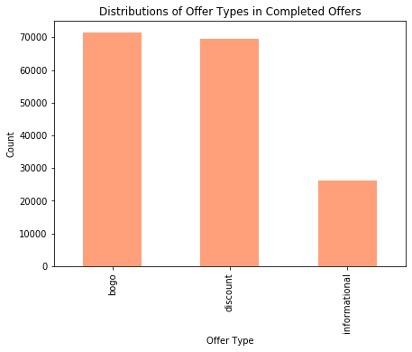

```python
ax = df_starbucks_master.groupby('offer_type')['offer completed'].count().plot(kind='bar' ,figsize=(7,5)  , title= "Distributions of Offer Types in Completed Offers", color="lightsalmon");
ax.set_xlabel("Offer Type")
ax.set_ylabel("Count");
```

> you can see that offers are most popular are Bogo (Buy one get one) followed closely by Discount offers then Informational offer.

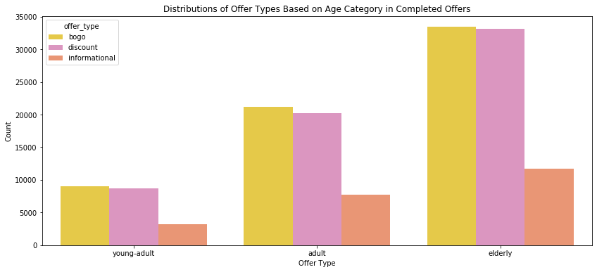

```python
plt.figure(figsize=(14, 6))
sns.countplot(x="age_category", hue="offer_type", data=df_starbucks_master,palette="Set2_r")
plt.title( "Distributions of Offer Types Based on Age Category in Completed Offers");
plt.xlabel("Offer Type")
plt.ylabel("Count");
```

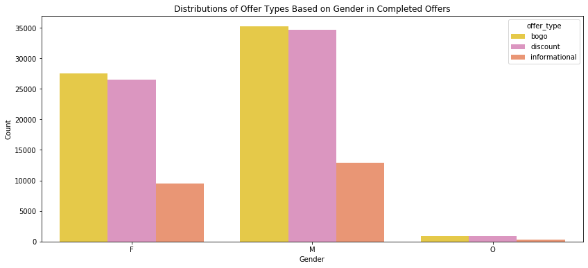

```python
plt.figure(figsize=(14, 6))
sns.countplot(x="gender", hue="offer_type", data=df_starbucks_master,palette="Set2_r")
plt.title( "Distributions of Offer Types Based on Gender in Completed Offers");
plt.xlabel("Gender")
plt.ylabel("Count");
```

## Conclusion

Finally, after analyzing the data, I found the following:

## Improvements

To make our results even better, I feel information about customers was limited we only had just age, gender, and income.it would better to have more features of the customers.